# HF EOL

Mégane

2023-03-28

```
##     datetime                    temperature       salinity         oxygen
##  Min.   :2013-09-16 14:00:00   Min.   :12.87   Min.   :34.98   Min.   : NA
##  1st Qu.:2018-06-28 19:15:00   1st Qu.:15.22   1st Qu.:37.84   1st Qu.: NA
##  Median :2020-02-08 21:30:00   Median :18.44   Median :38.02   Median : NA
##  Mean   :2019-11-01 12:10:12   Mean   :19.41   Mean   :37.98   Mean   :NaN
##  3rd Qu.:2021-08-07 04:45:00   3rd Qu.:23.86   3rd Qu.:38.15   3rd Qu.: NA
##  Max.   :2023-03-22 08:00:00   Max.   :29.15   Max.   :38.46   Max.   : NA
##                                                NA's   :778     NA's   :49318
##   Year.Month            Year           Year.Month.Day        Month
##  Length:49318       Length:49318       Length:49318       Length:49318
##  Class :character   Class :character   Class :character   Class :character
##  Mode  :character   Mode  :character   Mode  :character   Mode  :character
##
##
##
##
```

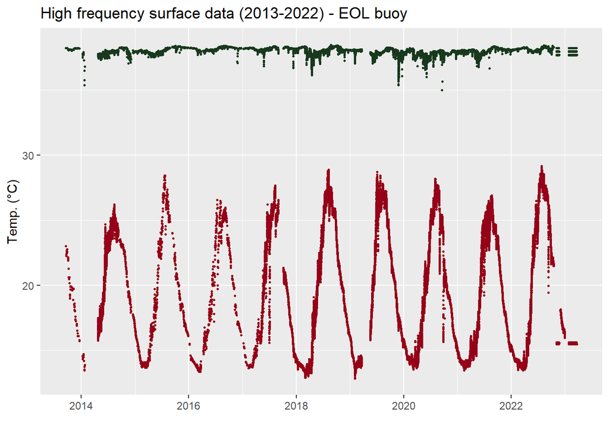

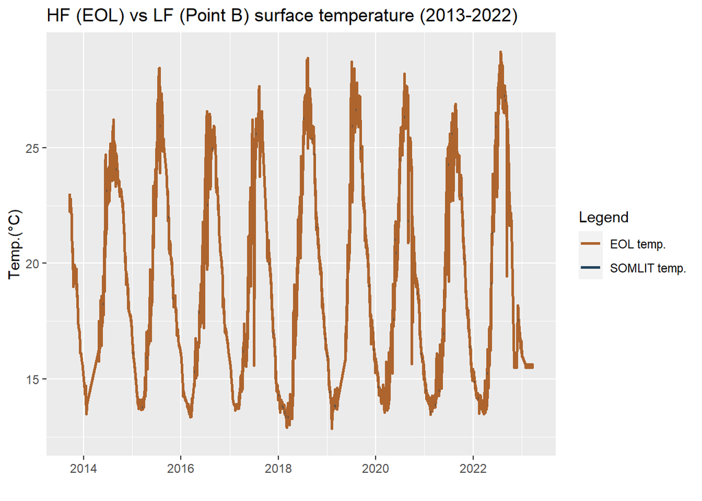

Scatter plot (T°) :  
Slope : 1.003  
Intercept : 0.040

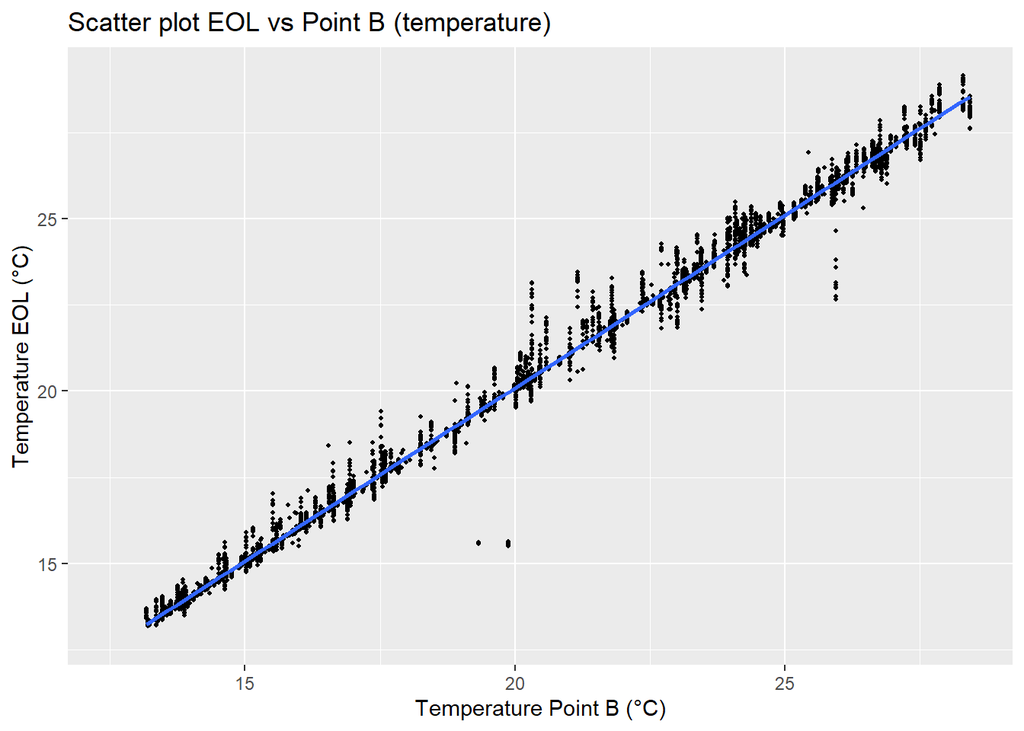

## Data EOL surface : temperature (°C) & salinity

#### Part 1 : Trend analysis by residuals : raw dataset

###### Table and plot of monthly means (2013-2022) - EOL temperature & salinity

```r
monthly_means <- ungroup(EOL_RAW) %>%
  mutate(Month = format(datetime, format="%m")) %>%
  group_by(Month) %>%
  summarise(
    Salinity_month = mean(salinity, na.rm = TRUE),
    Temperature_month = mean(temperature, na.rm = TRUE))

monthly_means
```

```
## # A tibble: 12 x 3
##    Month Salinity_month Temperature_month
##    <chr>          <dbl>             <dbl>
##  1 01              38.0              14.6
##  2 02              38.0              14.2
##  3 03              37.9              14.1
##  4 04              37.9              15.2
##  5 05              37.8              18.2
##  6 06              37.8              22.4
##  7 07              38.0              25.6
##  8 08              38.1              26.3
##  9 09              38.2              24.5
## 10 10              38.1              21.1
## 11 11              38.0              18.1
## 12 12              38.0              16.2
```

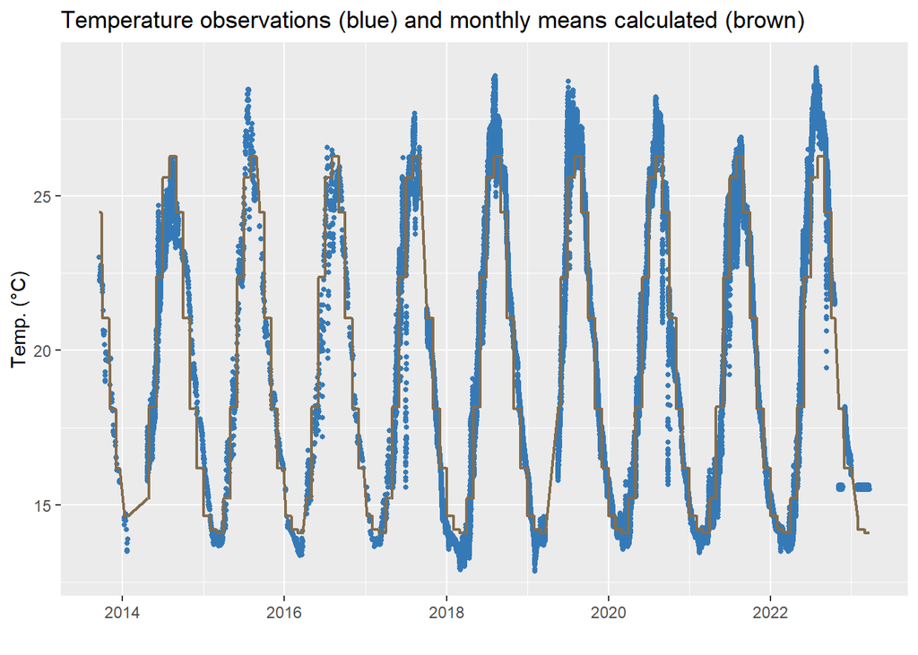

```r
EOL_monthly_means <- left_join(ungroup(EOL_RAW), monthly_means, by = "Month")

#plot
EOL_monthly_means %>%
  ggplot() +
  ggtitle("Temperature observations (blue) and monthly means calculated (brown)") +
  geom_point(aes(x=datetime, y=temperature), size=1, col="#357AB7") +
  geom_line(aes(x=datetime, y=Temperature_month), size=0.8, col="#856D4D") +
  scale_x_datetime(name="") +
  scale_y_continuous(name="Temp. (°C)")
```

###### Table of time series anomalies regression analyses (2013-2022) - EOL temperature & salinity

```
##                        Slope    SE Slope     P Slope   Intercept   SE int.
## Salinity_ano    -0.001199952 0.000434648 0.005769134    2.423645 0.8778959
## Temperature_ano  0.103860696 0.002496970 0.000000000 -209.781294 5.0434670
##                      P int.           F    df          R2     P value
## Salinity_ano    0.005769164    7.621713 48538 0.000157001 0.005769134
## Temperature_ano 0.000000000 1730.117857 49316 0.033893231 0.000000000
```

**Plot of anomalies : Temperature (°C) (2013-2022) - EOL**

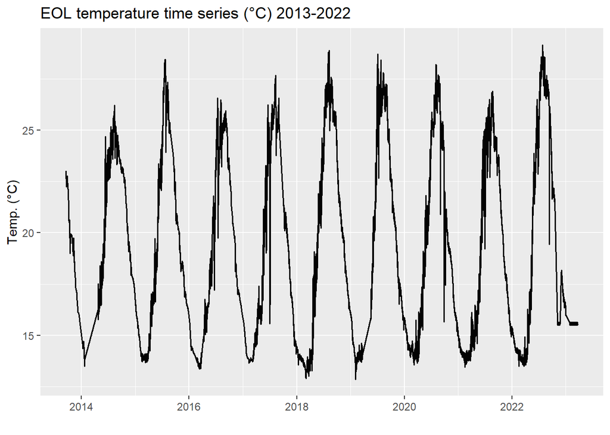

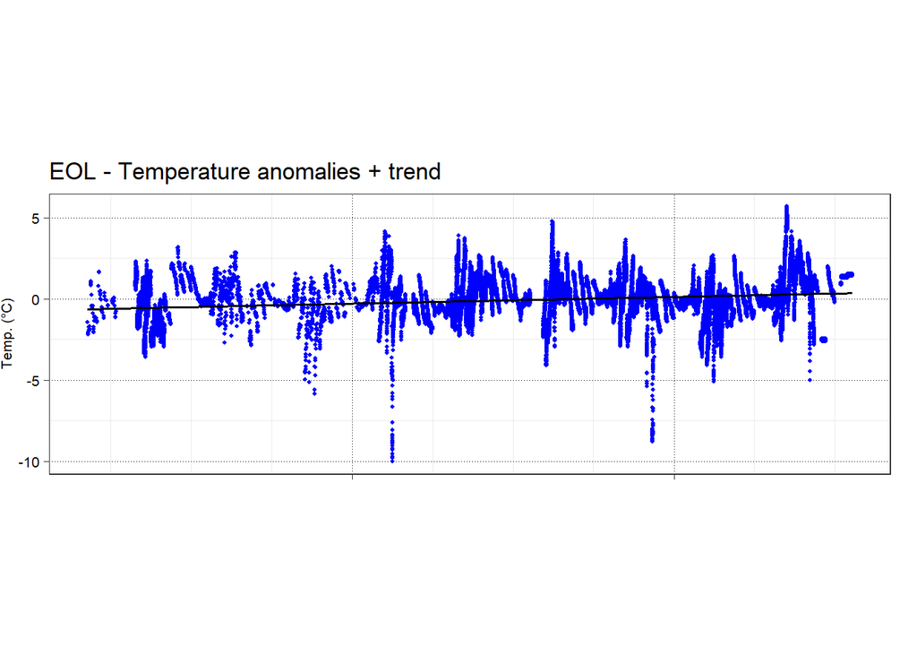

**Plot of anomalies : Salinity (2013-2022) - EOL**

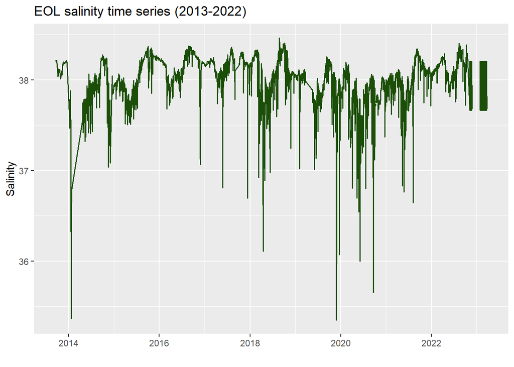

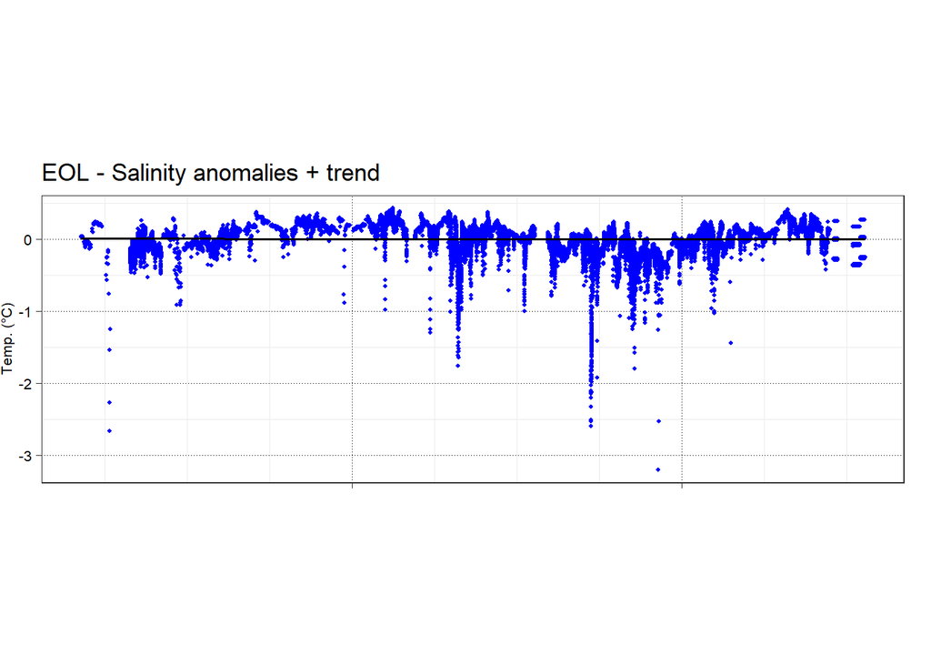

[figure not shown]

#### Part 2 : Trend analysis by residuals : daily dataset (morning 8AM-10AM) 2017-2022

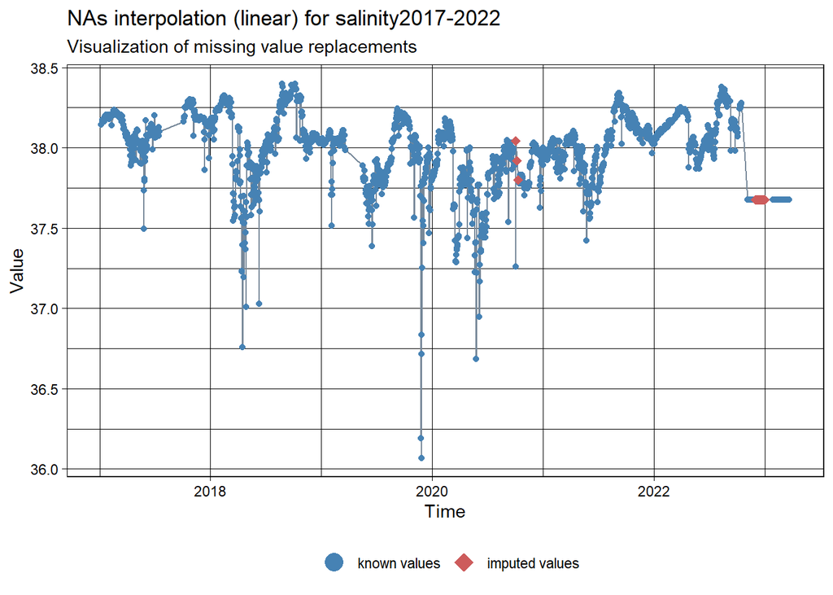

###### EOL 1 : Table and plot of monthly means (2017-2022) - EOL temperature & salinity

```r
monthly_means_EOL1 <- ungroup(EOL_daily) %>%
  mutate(Month = format(datetime, format="%m")) %>%
  group_by(Month) %>%
  summarise(
    Salinity_month = mean(salinity, na.rm = TRUE),
    Temperature_month = mean(temperature, na.rm = TRUE))

monthly_means_EOL1
```

```
## # A tibble: 12 x 3
##    Month Salinity_month Temperature_month
##    <chr>          <dbl>             <dbl>
##  1 01              38.1              14.6
##  2 02              38.0              14.1
##  3 03              38.0              14.0
##  4 04              37.9              15.0
##  5 05              37.8              18.0
##  6 06              37.8              22.2
##  7 07              37.9              25.7
##  8 08              38.1              26.5
##  9 09              38.2              24.4
## 10 10              38.2              21.0
## 11 11              38.0              18.1
## 12 12              38.0              16.2
```

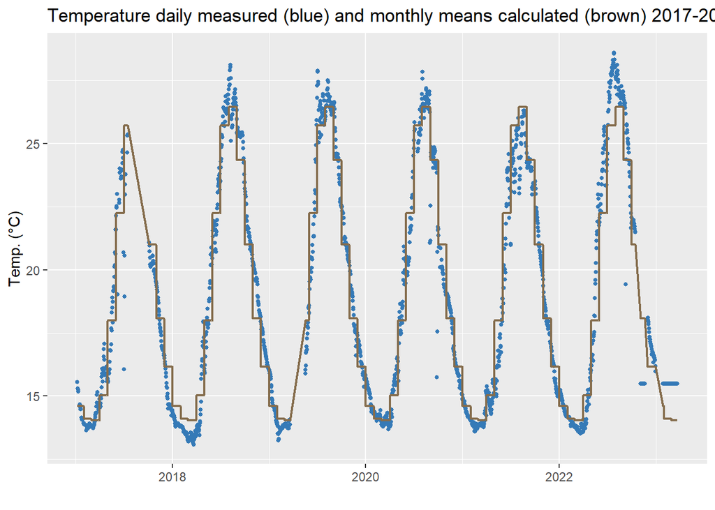

```r
EOL_1_monthly_means <- left_join(ungroup(EOL_daily), monthly_means_EOL1, by = "Month")

#plot
EOL_1_monthly_means %>%
  ggplot() +
  ggtitle("Temperature daily measured (blue) and monthly means calculated (brown) 2017-2022") +
  geom_point(aes(x=datetime, y=temperature), size=1, col="#357AB7") +
  geom_line(aes(x=datetime, y=Temperature_month), size=0.8, col="#856D4D") +
  scale_x_datetime(name="") +
  scale_y_continuous(name="Temp. (°C)")
```

###### EOL 1 : Table of time series anomalies regression analyses (2017-2022) - EOL temperature & salinity

```
##                       Slope    SE Slope      P Slope  Intercept   SE int.
## Salinity_ano    -0.01904220 0.002702672 2.543559e-12   38.46847  5.459858
## Temperature_ano  0.05605495 0.015997450 4.684278e-04 -113.24299 32.318286
##                       P int.        F   df          R2      P value
## Salinity_ano    2.543604e-12 49.64180 1964 0.024652745 2.543559e-12
## Temperature_ano 4.684300e-04 12.27796 1998 0.006107595 4.684278e-04
```

**EOL 1 : Plot of anomalies : Temperature (°C) (2017-2022) - EOL**

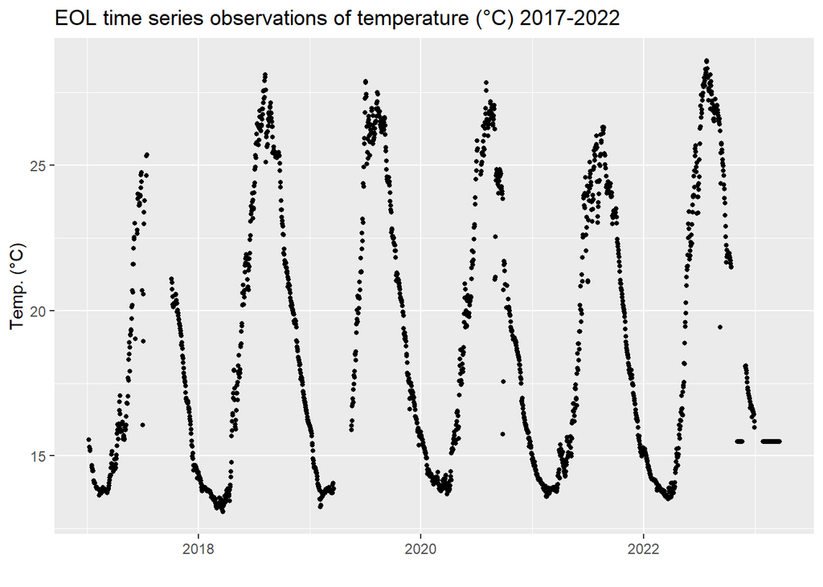

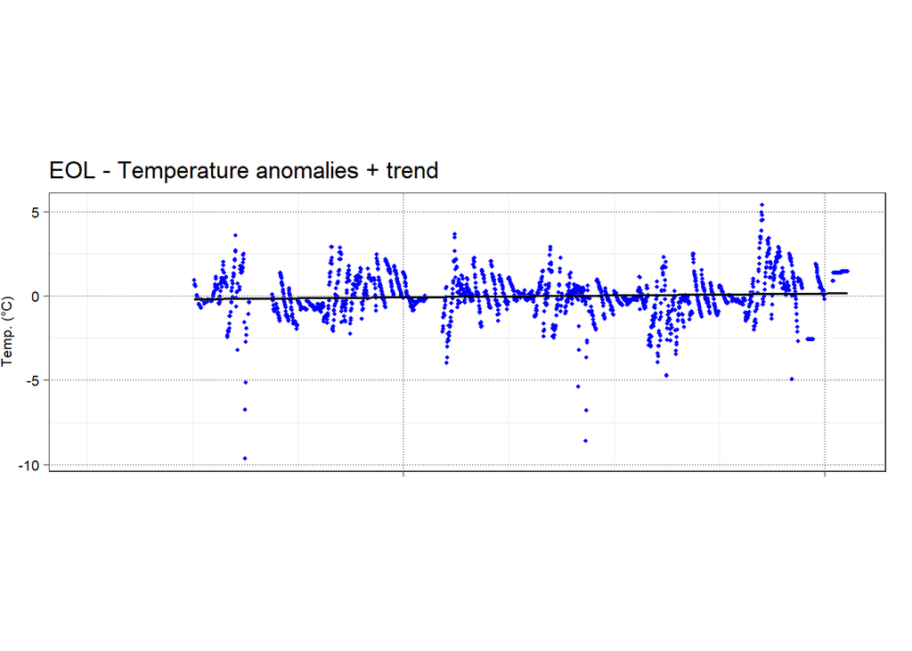

**EOL 1 : Plot of anomalies : Salinity (2017-2022) - EOL**

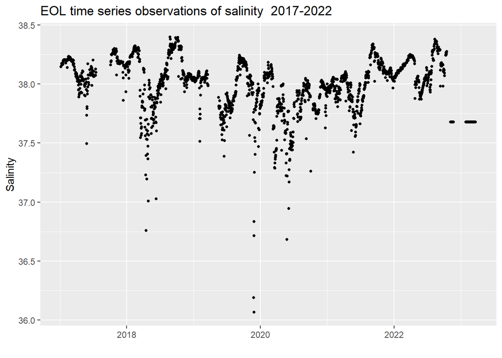

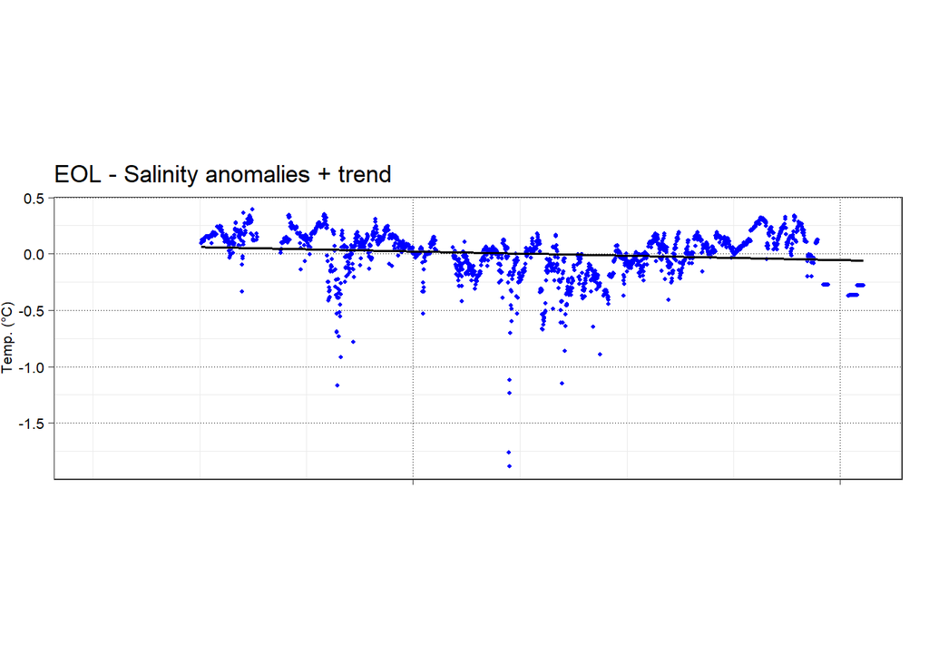

#### Part 3 : Trend analysis by residuals : daily dataset (morning + afternoon) 2017-2022

###### EOL 2 : Table and plot of monthly means (2017-2022) - EOL temperature & salinity

```r
monthly_means_EOL2 <- ungroup(EOL_daily_2) %>%
  mutate(Month = format(datetime, format="%m")) %>%
  group_by(Month) %>%
  summarise(
    Salinity_month = mean(salinity, na.rm = TRUE),
    Temperature_month = mean(temperature, na.rm = TRUE))

monthly_means_EOL2
```

```
## # A tibble: 12 x 3
##    Month Salinity_month Temperature_month
##    <chr>          <dbl>             <dbl>
##  1 01              38.0              14.6
##  2 02              38.0              14.2
##  3 03              37.9              14.1
##  4 04              37.9              15.1
##  5 05              37.8              18.3
##  6 06              37.8              22.5
##  7 07              37.9              25.9
##  8 08              38.1              26.7
##  9 09              38.2              24.5
## 10 10              38.2              21.1
## 11 11              38.0              18.1
## 12 12              38.0              16.2
```

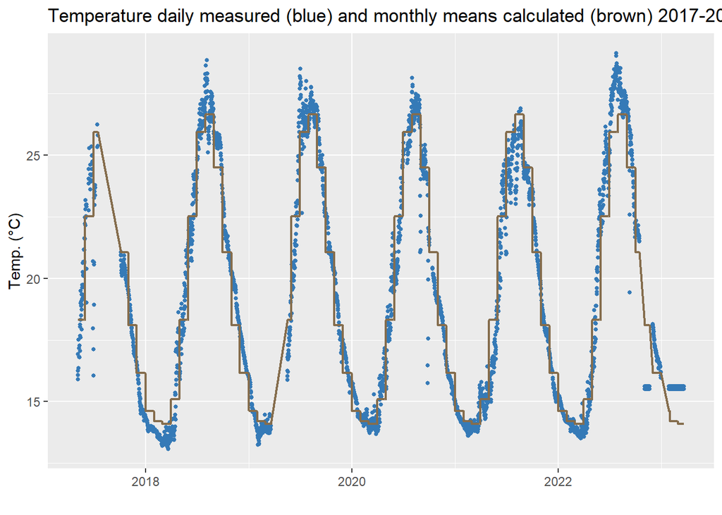

```r
EOL_2_monthly_means <- left_join(ungroup(EOL_daily_2), monthly_means_EOL2, by = "Month")

#plot
EOL_2_monthly_means %>%
  ggplot() +
  ggtitle("Temperature daily measured (blue) and monthly means calculated (brown) 2017-2022") +
  geom_point(aes(x=datetime, y=temperature), size=1, col="#357AB7") +
  geom_line(aes(x=datetime, y=Temperature_month), size=0.8, col="#856D4D") +
  scale_x_datetime(name="") +
  scale_y_continuous(name="Temp. (°C)")
```

###### EOL 2 : Table of time series anomalies regression analyses (2017-2022) - EOL temperature & salinity

```
##                       Slope    SE Slope      P Slope  Intercept   SE int.
## Salinity_ano    -0.01228548 0.002161082 1.409543e-08   24.82066  4.366089
## Temperature_ano  0.06401905 0.012593139 3.881665e-07 -129.34201 25.442778
##                       P int.        F   df          R2      P value
## Salinity_ano    1.409558e-08 32.31781 3726 0.008599008 1.409543e-08
## Temperature_ano 3.881698e-07 25.84344 3788 0.006776221 3.881665e-07
```

**EOL 2 : Plot of anomalies : Temperature (°C) (2017-2022) - EOL**

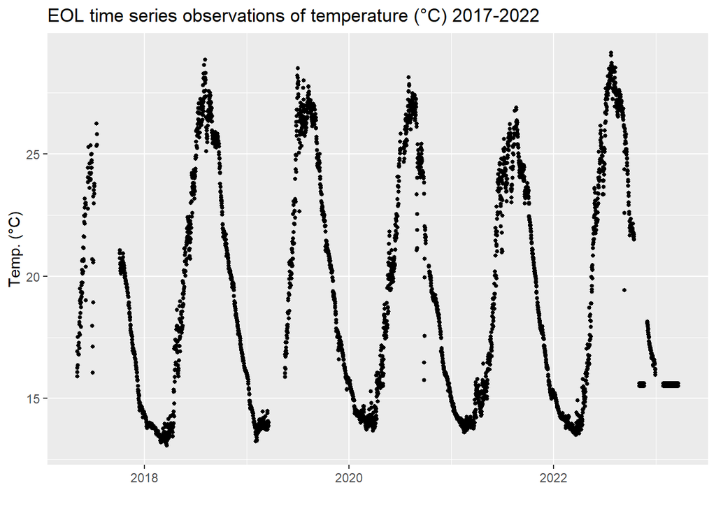

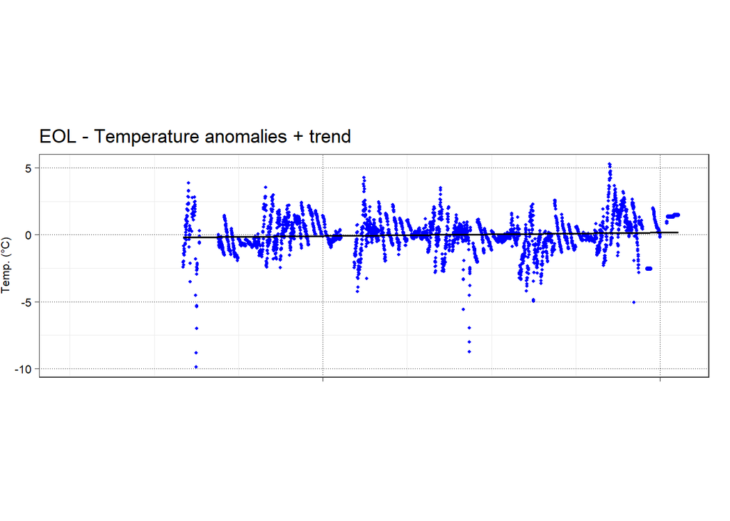

**EOL 2 : Plot of anomalies : Salinity (2017-2022) - EOL**

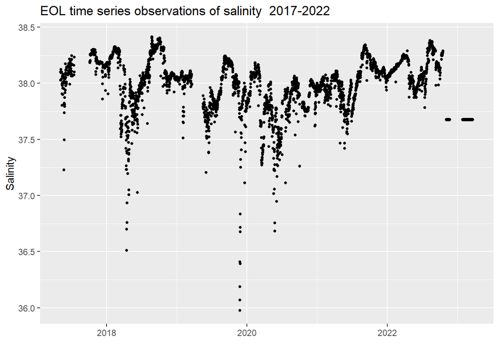

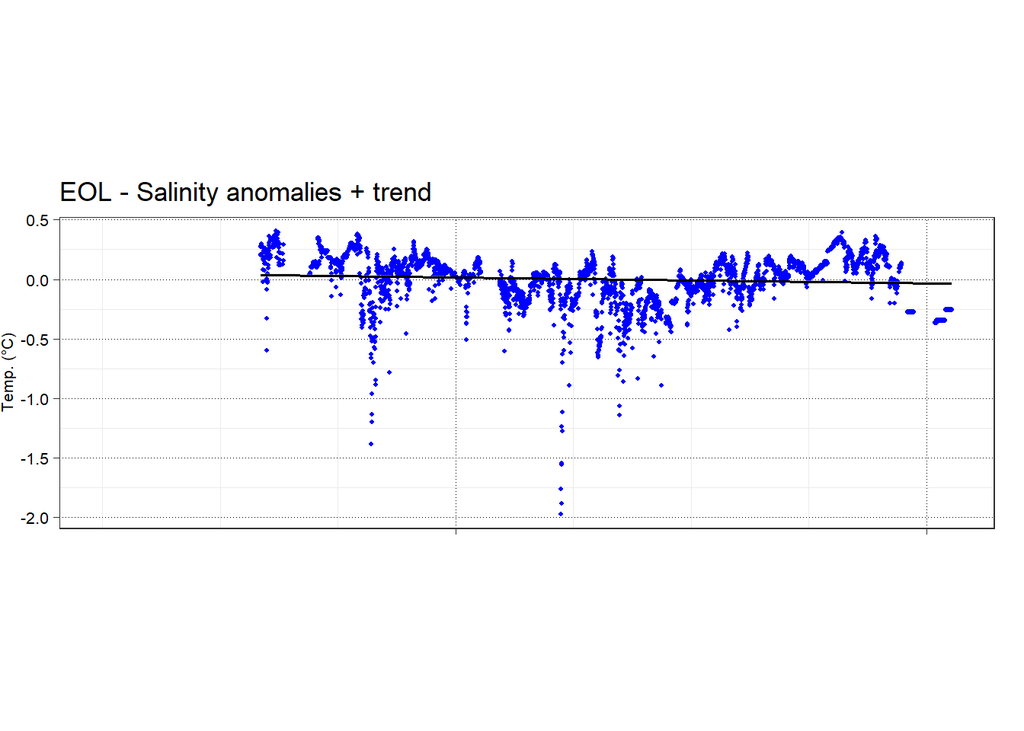

#### Part 4 : Trend analysis by residuals : hourly dataset 2017-2022

###### EOL 3 : Table and plot of monthly means (2017-2022) - EOL temperature & salinity

```r
monthly_means_EOL3 <- ungroup(EOL_daily_3) %>%
  mutate(Month = format(datetime, format="%m")) %>%
  group_by(Month) %>%
  summarise(
    Salinity_month = mean(salinity, na.rm = TRUE),
    Temperature_month = mean(temperature, na.rm = TRUE))

monthly_means_EOL3
```

```
## # A tibble: 12 x 3
##    Month Salinity_month Temperature_month
##    <chr>          <dbl>             <dbl>
##  1 01              38.0              14.6
##  2 02              38.0              14.2
##  3 03              37.9              14.1
##  4 04              37.9              15.1
##  5 05              37.8              18.2
##  6 06              37.8              22.4
##  7 07              37.9              26.1
##  8 08              38.1              26.7
##  9 09              38.2              24.5
## 10 10              38.1              21.0
## 11 11              38.0              18.1
## 12 12              38.0              16.2
```

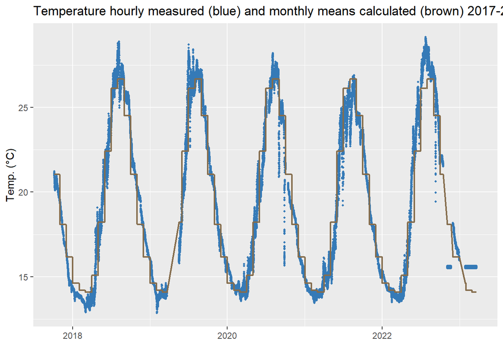

```r
EOL_3_monthly_means <- left_join(ungroup(EOL_daily_3), monthly_means_EOL3, by = "Month")

#plot
EOL_3_monthly_means %>%
  ggplot() +
  ggtitle("Temperature hourly measured (blue) and monthly means calculated (brown) 2017-2022") +
  geom_point(aes(x=datetime, y=temperature), size=0.8, col="#357AB7") +
  geom_line(aes(x=datetime, y=Temperature_month), size=0.8, col="#856D4D") +
  scale_x_datetime(name="") +
  scale_y_continuous(name="Temp. (°C)")
```

###### EOL 3 : Table of time series anomalies regression analyses (2017-2022) - EOL temperature & salinity

```
##                        Slope     SE Slope     P Slope   Intercept  SE int.
## Salinity_ano    -0.004437699 0.0006823211 7.91758e-11    8.965947 1.378565
## Temperature_ano  0.073771130 0.0037116050 1.63593e-87 -149.050781 7.499110
##                       P int.         F    df          R2     P value
## Salinity_ano    7.917679e-11  42.29979 42120 0.001003261 7.91758e-11
## Temperature_ano 1.636120e-87 395.04754 42881 0.009128549 1.63593e-87
```

**EOL 3 : Plot of anomalies : Temperature (°C) (2017-2022) - EOL**

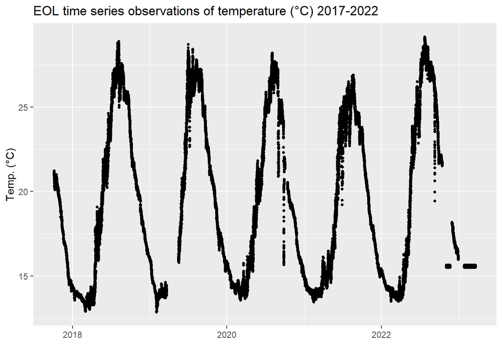

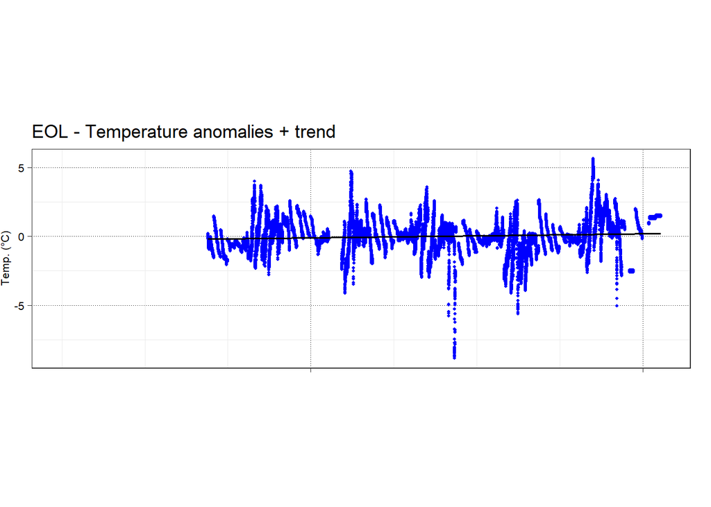

**EOL 3 : Plot of anomalies : Salinity (2017-2022) - EOL**

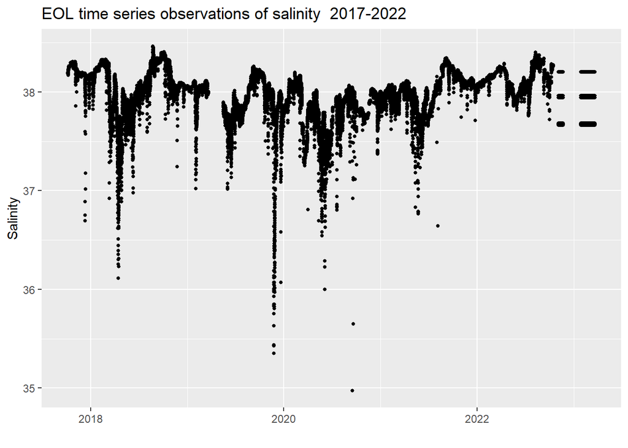

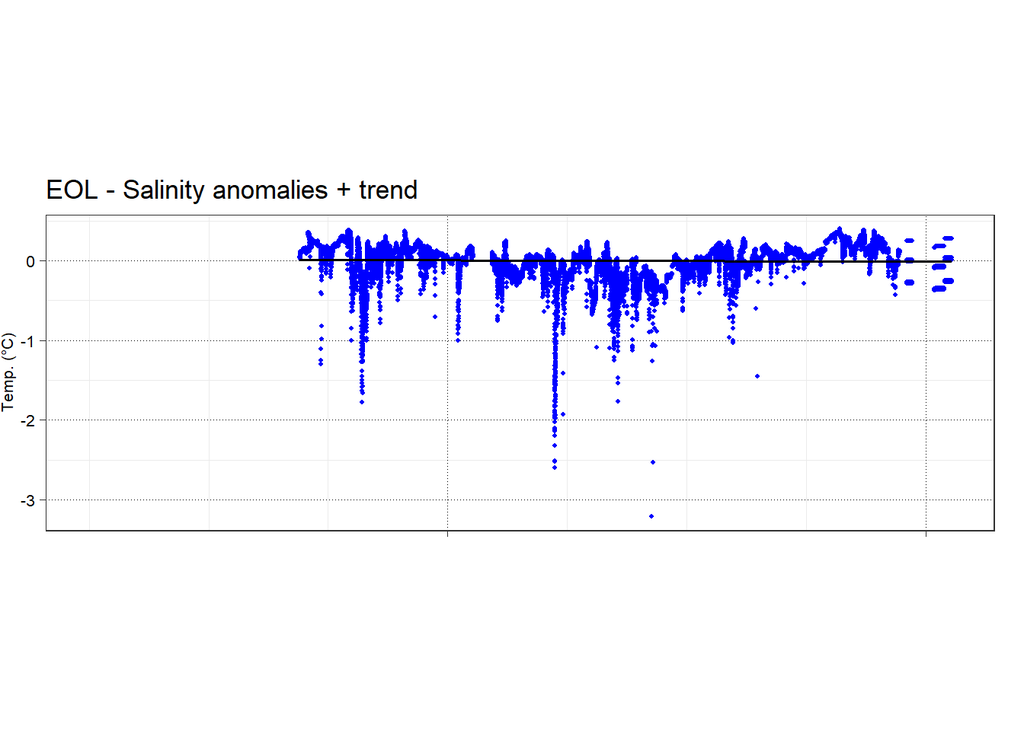

### Summary table of regression analyses on residuals :

```r
table_test <- data.frame(reg_raw, reg_EOL_1, reg_EOL_2, reg_EOL_3)

summary_table <- data.frame(table_test$Slope, table_test$P.Slope, table_test$Slope.1, table_test$P.Slope.1,
                   table_test$Slope.2, table_test$P.Slope.2, table_test$Slope.3,table_test$P.Slope.3)

colnames(summary_table) <- c("EOL_raw_slope", "EOL_raw_pvalue", "EOL_daily_slope", "EOL_daily_pvalue",
                             "EOL_daily_2_slope", "EOL_daily_2_pvalue", "EOL_hourly_slope", "EOL_hourly_pvalue")
rownames(summary_table) <- c("Salinity_anomalies", "Temperature_anomalies")

summary_table
```

```
##                       EOL_raw_slope EOL_raw_pvalue EOL_daily_slope
## Salinity_anomalies     -0.001199952    0.005769134     -0.01904220
## Temperature_anomalies   0.103860696    0.000000000      0.05605495
##                       EOL_daily_pvalue EOL_daily_2_slope EOL_daily_2_pvalue
## Salinity_anomalies        2.543559e-12       -0.01228548       1.409543e-08
## Temperature_anomalies     4.684278e-04        0.06401905       3.881665e-07
##                       EOL_hourly_slope EOL_hourly_pvalue
## Salinity_anomalies        -0.004437699       7.91758e-11
## Temperature_anomalies      0.073771130       1.63593e-87
```

## Comparison between EOL and Azur buoy - SST data 2013-2022

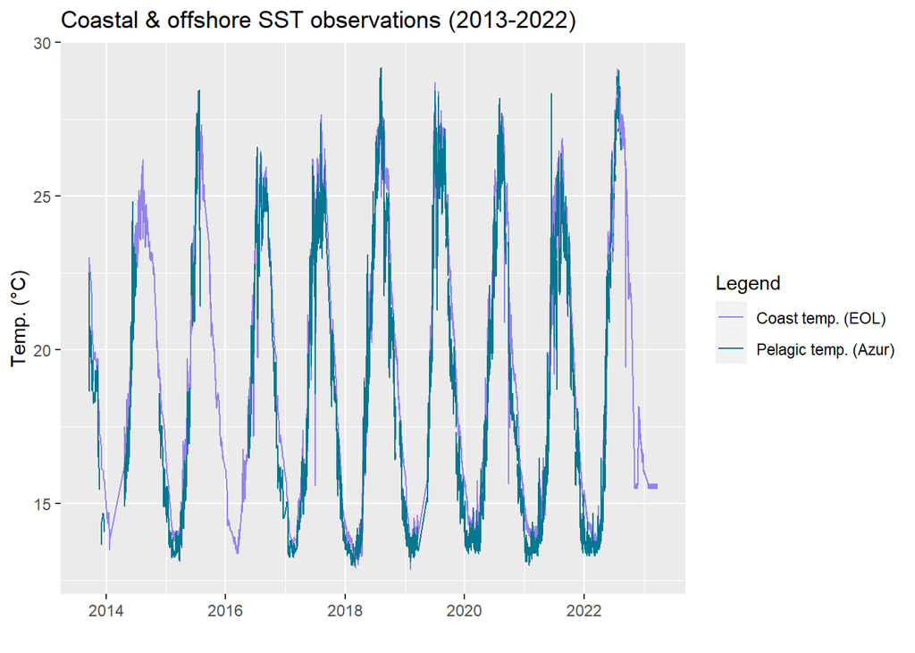

*Slope : 0.9993014*  
*Intercept : 0.7620216*

```
##
## Call:
## lm(formula = temperature ~ temp_pelag, data = pelagic_coast)
##
## Residuals:
##     Min      1Q  Median      3Q     Max
## -5.9506 -0.4714 -0.0949  0.4408  4.8468
##
## Coefficients:
##              Estimate Std. Error t value Pr(>|t|)
## (Intercept) 0.7620216  0.0174061   43.78   <2e-16 ***
## temp_pelag  0.9993014  0.0009255 1079.71   <2e-16 ***
## ---
## Signif. codes:  0 '***' 0.001 '**' 0.01 '*' 0.05 '.' 0.1 ' ' 1
##
## Residual standard error: 0.8308 on 40393 degrees of freedom
##   (8923 observations effacées parce que manquantes)
## Multiple R-squared:  0.9665, Adjusted R-squared:  0.9665
## F-statistic: 1.166e+06 on 1 and 40393 DF,  p-value: < 2.2e-16
```

## Wind speed data (m/s)

→ Comparison between wind EOL modelisation and wind data of St-Jean-Cap-Ferrat station :

*model EOL : Jan.2009 - Dec.2022*  
*data Cap-Ferrat : Dec.2020 - Jan.2022*

Frequency : hourly  
Unity : m/s

##### **Histogram of wind speed distribution : model vs Cap-Ferrat**

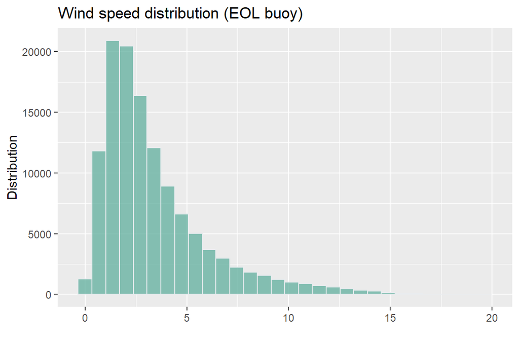

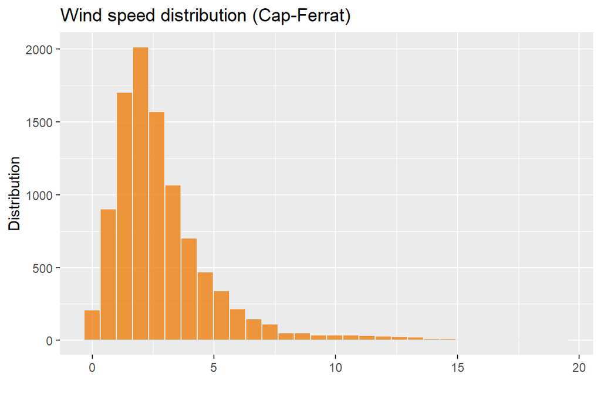

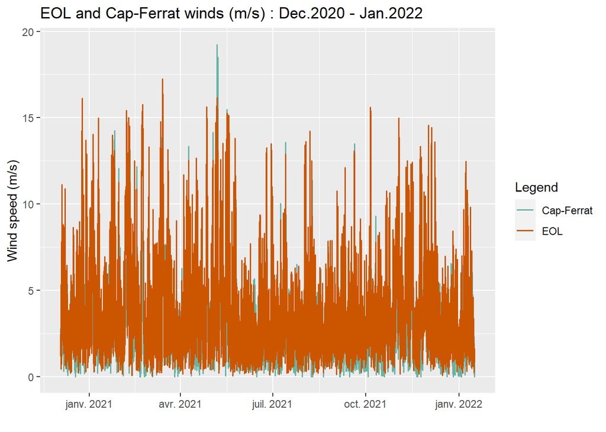

##### Scatterplot EOL vs Cap-Ferrat (wind speed m/s 10m) :

*Slope : 0.87 ± 0.01*  
*Intercept : 1.41 ± 0.037*

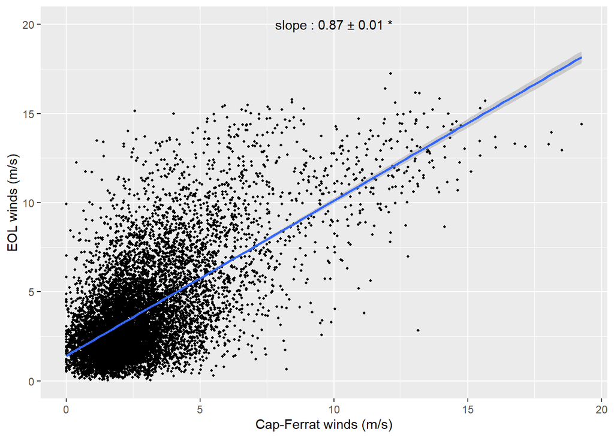

## Heatwaves :

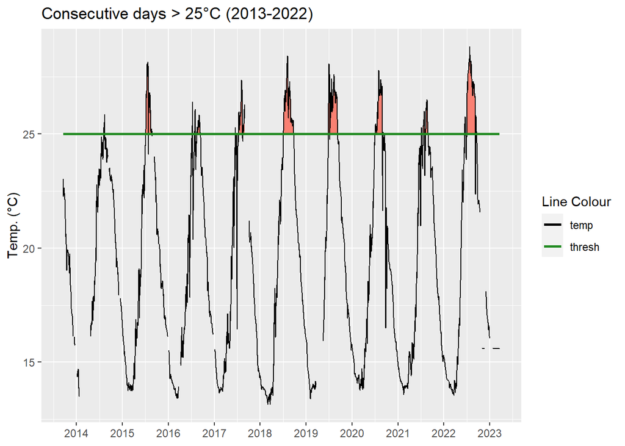

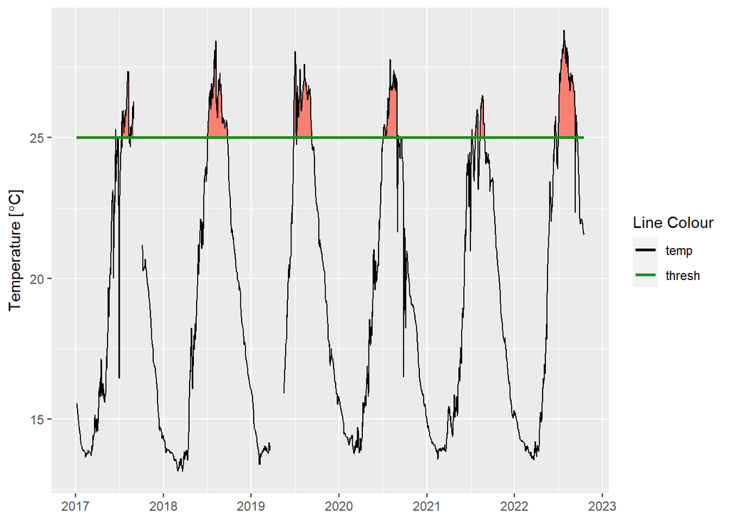